# House Prices - Advanced Regression Techniques2

load the required packages first

```r
library(mlr,quietly = TRUE)
library(dplyr,quietly = TRUE)
library(ggplot2,quietly = TRUE)
library(caret,quietly = TRUE)
library(purrr,quietly = TRUE)
library(data.table,quietly = TRUE,warn.conflicts = FALSE)
library(readr,quietly = TRUE,warn.conflicts = FALSE)
```

Load the test and train datasets

```r
test=read_csv("test.csv")
```

Rbind the two datasets to perform feature engineering, will later separate the two datasets again. Remove the variable Sale Price from the training set

```r
a
```

[output not shown]

Find the str of the combined train_test dataset. Also take the summary

```r
summary(train_test)
```

```
       Id           MSSubClass       MSZoning          LotFrontage        LotArea          Street
 Min.   :   1.0   Min.   : 20.00   Length:2919        Min.   : 21.00   Min.   :  1300   Length:2919
 1st Qu.: 730.5   1st Qu.: 20.00   Class :character   1st Qu.: 59.00   1st Qu.:  7478   Class :character
 Median :1460.0   Median : 50.00   Mode  :character   Median : 68.00   Median :  9453   Mode  :character
 Mean   :1460.0   Mean   : 57.14                      Mean   : 69.31   Mean   : 10168
 3rd Qu.:2189.5   3rd Qu.: 70.00                      3rd Qu.: 80.00   3rd Qu.: 11570
 Max.   :2919.0   Max.   :190.00                      Max.   :313.00   Max.   :215245
                                                      NA's   :486
    Alley             LotShape         LandContour         Utilities          LotConfig
 Length:2919        Length:2919        Length:2919        Length:2919        Length:2919
 Class :character   Class :character   Class :character   Class :character   Class :character
 Mode  :character   Mode  :character   Mode  :character   Mode  :character   Mode  :character




  LandSlope         Neighborhood        Condition1         Condition2          BldgType
 Length:2919        Length:2919        Length:2919        Length:2919        Length:2919
 Class :character   Class :character   Class :character   Class :character   Class :character
 Mode  :character   Mode  :character   Mode  :character   Mode  :character   Mode  :character




  HouseStyle         OverallQual      OverallCond      YearBuilt     YearRemodAdd   RoofStyle
 Length:2919        Min.   : 1.000   Min.   :1.000   Min.   :1872   Min.   :1950   Length:2919
 Class :character   1st Qu.: 5.000   1st Qu.:5.000   1st Qu.:1954   1st Qu.:1965   Class :character
 Mode  :character   Median : 6.000   Median :5.000   Median :1973   Median :1993   Mode  :character
                    Mean   : 6.089   Mean   :5.565   Mean   :1971   Mean   :1984
                    3rd Qu.: 7.000   3rd Qu.:6.000   3rd Qu.:2001   3rd Qu.:2004
                    Max.   :10.000   Max.   :9.000   Max.   :2010   Max.   :2010

   RoofMatl         Exterior1st        Exterior2nd         MasVnrType          MasVnrArea      ExterQual
 Length:2919        Length:2919        Length:2919        Length:2919        Min.   :   0.0   Length:2919
 Class :character   Class :character   Class :character   Class :character   1st Qu.:   0.0   Class :character
 Mode  :character   Mode  :character   Mode  :character   Mode  :character   Median :   0.0   Mode  :character
                                                                             Mean   : 102.2
                                                                             3rd Qu.: 164.0
                                                                             Max.   :1600.0
                                                                             NA's   :23
```

[output cut: 56 more lines]

```
   3SsnPorch        ScreenPorch        PoolArea          PoolQC             Fence           MiscFeature
 Min.   :  0.000   Min.   :  0.00   Min.   :  0.000   Length:2919        Length:2919        Length:2919
 1st Qu.:  0.000   1st Qu.:  0.00   1st Qu.:  0.000   Class :character   Class :character   Class :character
 Median :  0.000   Median :  0.00   Median :  0.000   Mode  :character   Mode  :character   Mode  :character
 Mean   :  2.602   Mean   : 16.06   Mean   :  2.252
 3rd Qu.:  0.000   3rd Qu.:  0.00   3rd Qu.:  0.000
 Max.   :508.000   Max.   :576.00   Max.   :800.000

    MiscVal             MoSold           YrSold       SaleType         SaleCondition
 Min.   :    0.00   Min.   : 1.000   Min.   :2006   Length:2919        Length:2919
 1st Qu.:    0.00   1st Qu.: 4.000   1st Qu.:2007   Class :character   Class :character
 Median :    0.00   Median : 6.000   Median :2008   Mode  :character   Mode  :character
 Mean   :   50.83   Mean   : 6.213   Mean   :2008
 3rd Qu.:    0.00   3rd Qu.: 8.000   3rd Qu.:2009
 Max.   :17000.00   Max.   :12.000   Max.   :2010
```

Take all ‘Character’ class types and convert to factor (categorical) types. Add other numeric variables identified above and convert to factor

```r
str(trn_tst_chr)
```

```
Classes ‘tbl_df’, ‘tbl’ and 'data.frame':   2919 obs. of  47 variables:
 $ MSZoning     : Factor w/ 5 levels "C (all)","FV",..: 4 4 4 4 4 4 4 4 5 4 ...
 $ Street       : Factor w/ 2 levels "Grvl","Pave": 2 2 2 2 2 2 2 2 2 2 ...
 $ Alley        : Factor w/ 2 levels "Grvl","Pave": NA NA NA NA NA NA NA NA NA NA ...
 $ LotShape     : Factor w/ 4 levels "IR1","IR2","IR3",..: 4 4 1 1 1 1 4 1 4 4 ...
 $ LandContour  : Factor w/ 4 levels "Bnk","HLS","Low",..: 4 4 4 4 4 4 4 4 4 4 ...
 $ Utilities    : Factor w/ 2 levels "AllPub","NoSeWa": 1 1 1 1 1 1 1 1 1 1 ...
 $ LotConfig    : Factor w/ 5 levels "Corner","CulDSac",..: 5 3 5 1 3 5 5 1 5 1 ...
 $ LandSlope    : Factor w/ 3 levels "Gtl","Mod","Sev": 1 1 1 1 1 1 1 1 1 1 ...
 $ Neighborhood : Factor w/ 25 levels "Blmngtn","Blueste",..: 6 25 6 7 14 12 21 17 18 4 ...
 $ Condition1   : Factor w/ 9 levels "Artery","Feedr",..: 3 2 3 3 3 3 3 5 1 1 ...
 $ Condition2   : Factor w/ 8 levels "Artery","Feedr",..: 3 3 3 3 3 3 3 3 3 1 ...
 $ BldgType     : Factor w/ 5 levels "1Fam","2fmCon",..: 1 1 1 1 1 1 1 1 1 2 ...
 $ HouseStyle   : Factor w/ 8 levels "1.5Fin","1.5Unf",..: 6 3 6 6 6 1 3 6 1 2 ...
 $ RoofStyle    : Factor w/ 6 levels "Flat","Gable",..: 2 2 2 2 2 2 2 2 2 2 ...
```

[output cut: 33 more lines]

find the number of NAs in each of the factor variables

```r
colSums(sapply(trn_tst_chr,is.na))
```

```
     MSZoning        Street         Alley      LotShape   LandContour     Utilities     LotConfig     LandSlope
            4             0          2721             0             0             2             0             0
 Neighborhood    Condition1    Condition2      BldgType    HouseStyle     RoofStyle      RoofMatl   Exterior1st
            0             0             0             0             0             0             0             1
  Exterior2nd    MasVnrType     ExterQual     ExterCond    Foundation      BsmtQual      BsmtCond  BsmtExposure
            1            24             0             0             0            81            82            82
 BsmtFinType1  BsmtFinType2       Heating     HeatingQC    CentralAir    Electrical   KitchenQual    Functional
           79            80             0             0             0             1             1             2
  FireplaceQu    GarageType  GarageFinish    GarageQual    GarageCond    PavedDrive        PoolQC         Fence
         1420           157           159           159           159             0          2909          2348
  MiscFeature      SaleType SaleCondition    MSSubClass   OverallQual   OverallCond        MoSold
         2814             1             0             0             0             0             0
```

Variables Alley, FireplaceQu, PoolQC, Fence, MiscFeature have very high NAs and are removed

```r
colSums(sapply(trn_tst_chr,is.na))
```

```
     MSZoning        Street      LotShape   LandContour     Utilities     LotConfig     LandSlope  Neighborhood
            4             0             0             0             2             0             0             0
   Condition1    Condition2      BldgType    HouseStyle     RoofStyle      RoofMatl   Exterior1st   Exterior2nd
            0             0             0             0             0             0             1             1
   MasVnrType     ExterQual     ExterCond    Foundation      BsmtQual      BsmtCond  BsmtExposure  BsmtFinType1
           24             0             0             0            81            82            82            79
 BsmtFinType2       Heating     HeatingQC    CentralAir    Electrical   KitchenQual    Functional    GarageType
           80             0             0             0             1             1             2           157
 GarageFinish    GarageQual    GarageCond    PavedDrive      SaleType SaleCondition    MSSubClass   OverallQual
          159           159           159             0             1             0             0             0
  OverallCond        MoSold
            0             0
```

Perform imputation of missing factor levels using mode. Use ‘Impute’ function from mlr package

```r
colSums(sapply(trn_tst_chr,is.na))
```

```
     MSZoning        Street      LotShape   LandContour     Utilities     LotConfig     LandSlope  Neighborhood
            0             0             0             0             0             0             0             0
   Condition1    Condition2      BldgType    HouseStyle     RoofStyle      RoofMatl   Exterior1st   Exterior2nd
            0             0             0             0             0             0             0             0
   MasVnrType     ExterQual     ExterCond    Foundation      BsmtQual      BsmtCond  BsmtExposure  BsmtFinType1
            0             0             0             0             0             0             0             0
 BsmtFinType2       Heating     HeatingQC    CentralAir    Electrical   KitchenQual    Functional    GarageType
            0             0             0             0             0             0             0             0
 GarageFinish    GarageQual    GarageCond    PavedDrive      SaleType SaleCondition    MSSubClass   OverallQual
            0             0             0             0             0             0             0             0
  OverallCond        MoSold
            0             0
```

Take all numerics variables separately

```r
trn_tst_numeric$YrSold=NULL
```

Find the number of NAs in the numeric variables

```r
colSums(sapply(trn_tst_numeric,is.na))
```

```
           Id   LotFrontage       LotArea    MasVnrArea    BsmtFinSF1    BsmtFinSF2     BsmtUnfSF   TotalBsmtSF
            0           486             0            23             1             1             1             1
     1stFlrSF      2ndFlrSF  LowQualFinSF     GrLivArea  BsmtFullBath  BsmtHalfBath      FullBath      HalfBath
            0             0             0             0             2             2             0             0
 BedroomAbvGr  KitchenAbvGr  TotRmsAbvGrd    Fireplaces    GarageCars    GarageArea    WoodDeckSF   OpenPorchSF
            0             0             0             0             1             1             0             0
EnclosedPorch     3SsnPorch   ScreenPorch      PoolArea       MiscVal      builtage remodelledage     garageage
            0             0             0             0             0             0             0           159
      soldAge
            0
```

```r
colSums(sapply(trn_tst_numeric,is.na))
```

```
           Id   LotFrontage       LotArea    MasVnrArea    BsmtFinSF1    BsmtFinSF2     BsmtUnfSF   TotalBsmtSF
            0             0             0             0             0             0             0             0
    X1stFlrSF     X2ndFlrSF  LowQualFinSF     GrLivArea  BsmtFullBath  BsmtHalfBath      FullBath      HalfBath
            0             0             0             0             0             0             0             0
 BedroomAbvGr  KitchenAbvGr  TotRmsAbvGrd    Fireplaces    GarageCars    GarageArea    WoodDeckSF   OpenPorchSF
            0             0             0             0             0             0             0             0
EnclosedPorch    X3SsnPorch   ScreenPorch      PoolArea       MiscVal      builtage remodelledage     garageage
            0             0             0             0             0             0             0             0
      soldAge
            0
```

Check and remove any constant features (min variation) as they don’t help in machine learning, The percentage of variabilitiy is kept at 5% meaning all features with below 5% variability are removed

```r
trn_tst_numeric=removeConstantFeatures(trn_tst_numeric,perc = 0.05)
```

```
Removing 5 columns: LowQualFinSF,KitchenAbvGr,X3SsnPorch,PoolArea,MiscVal
```

5 variables with low variance were removed. LowQualFinSF,KitchenAbvGr,X3SsnPorch,PoolArea,MiscVal Next visualize intra feature correlation. Load package corrplot

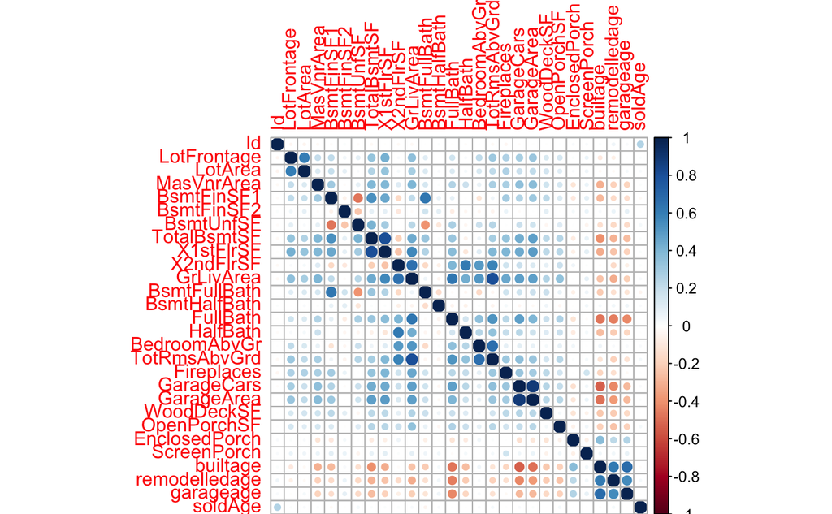

Find variables of high correlation with each other (multicollinearity) and remove them. Use findCorrelation function from Caret package. All variables with more than 70% correlation are flagged and removed

```r
names(trn_tst_numeric[,highcorvar])
```

```
[1] "GrLivArea"  "X1stFlrSF"  "GarageCars"
```

combine numeric, and factordatasets back together using cbind, remove other datasets that are no longer needed

```r
rm(trn_tst_chr,trn_tst_num,trn_tst_numeric,train_test,numcorr,highcorvar,imp_fctr,imp_num,YearBuilt)
```

```
object 'imp_num' not foundobject 'YearBuilt' not found
```

Separate out the train and test sets. Add the response variable ’SalePrice back to training dataset

```r
mod_train=train_test_mod[Id<1461,]
```

[output not shown]

We now begin with the supervised machine learning tasks. Create a regression task.

```r
house_regr
```

```
Supervised task: mod_train
Type: regr
Target: SalePrice
Observations: 1460
Features:
numerics  factors  ordered
      24       42        0
Missings: FALSE
Has weights: FALSE
Has blocking: FALSE
```

Build a benchmark experiment for selecting the best learner (algorithm). List all learners that can perform regression learning on this task

```r
regr_learners=listLearners(house_regr)
```

[output not shown]

```r
house_learn
```

```
[[1]]
Learner regr.gbm from package gbm
Type: regr
Name: Gradient Boosting Machine; Short name: gbm
Class: regr.gbm
Properties: missings,numerics,factors,weights,featimp
Predict-Type: response
Hyperparameters: distribution=gaussian,keep.data=FALSE


[[2]]
Learner regr.rpart from package rpart
Type: regr
Name: Decision Tree; Short name: rpart
Class: regr.rpart
Properties: missings,numerics,factors,ordered,weights,featimp
Predict-Type: response
Hyperparameters: xval=0


[[3]]
Learner regr.randomForest from package randomForest
Type: regr
Name: Random Forest; Short name: rf
Class: regr.randomForest
Properties: numerics,factors,ordered,se,featimp
Predict-Type: response
Hyperparameters: se.method=bootstrap,se.boot=50,ntree.for.se=100


[[4]]
Learner regr.ksvm from package kernlab
Type: regr
Name: Support Vector Machines; Short name: ksvm
Class: regr.ksvm
Properties: numerics,factors
Predict-Type: response
Hyperparameters: fit=FALSE


[[5]]
Learner regr.nnet from package nnet
Type: regr
Name: Neural Network; Short name: nnet
Class: regr.nnet
Properties: numerics,factors,weights
Predict-Type: response
Hyperparameters: size=3
```

Set the resampling strategy- we use cross validation with 3 iterations

```r
house_resamp
```

```
Resample description: cross-validation with 3 iterations.
Predict: test
Stratification: FALSE
```

list all measure that should be evaluated for selecting the best learner. We’ll use R Squared and MSE for evaluation purposes

```r
listMeasures(house_regr)
```

```
 [1] "rsq"         "rae"         "rmsle"       "mse"         "rrse"        "medse"       "mae"
 [8] "timeboth"    "timepredict" "medae"       "featperc"    "mape"        "rmse"        "sse"
[15] "arsq"        "expvar"      "msle"        "sae"         "timetrain"
```

Perform the benchmarking experiment to understand the best learners

```r
house_bench
```

```
    task.id        learner.id mse.test.mean rsq.test.mean
1 mod_train          regr.gbm    5790430199  0.0813204129
2 mod_train        regr.rpart    2118962244  0.6640814820
3 mod_train regr.randomForest     961319816  0.8473919873
4 mod_train         regr.ksvm     999092090  0.8414443984
5 mod_train         regr.nnet    6298605355  0.0006586294
```

Visualize results of the benchmarking experiment

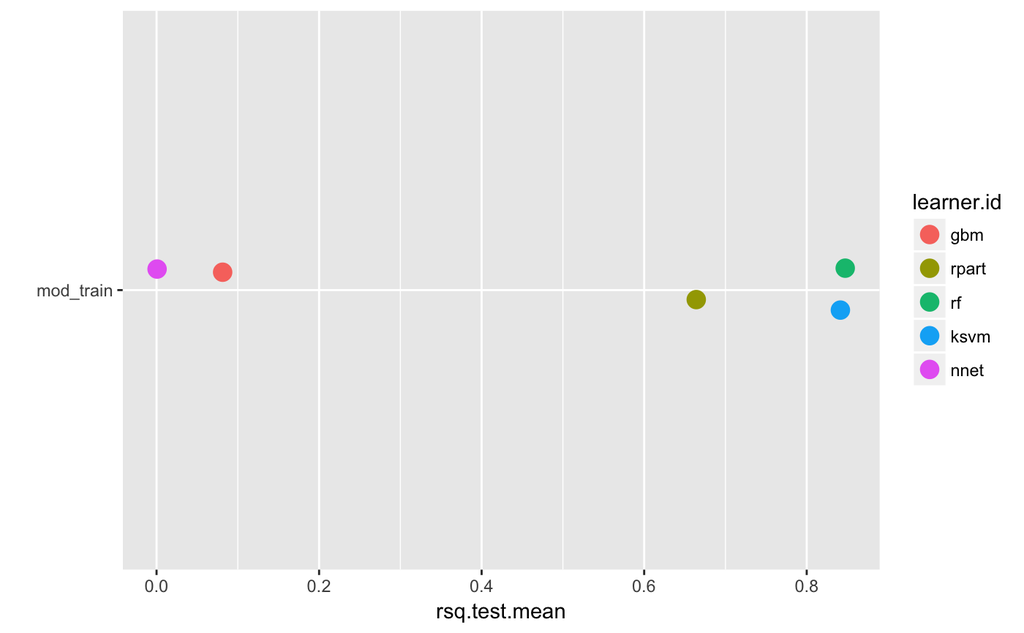

clearly support vector machine (ksvm) and random forest are the best algorithms giving an rsquared values of almost 85%

We’ll now build a prediction model using the Support Vector Machine algorithm. In first iteration, we’ll build the model using the default hyperparameters. Subsequently, we’ll do hyperparameter tuning

```r
house_trn1
```

```
Model for learner.id=regr.ksvm; learner.class=regr.ksvm
Trained on: task.id = mod_train; obs = 1460; features = 66
Hyperparameters: fit=FALSE
```

Predict using the trained model using the new test dataset

|  | response |
| --- | --- |
| 1 | 125937.97 |
| 2 | 151899.39 |
| 3 | 191168.45 |
| 4 | 201782.43 |
| 5 | 187810.98 |
| 6 | 175229.35 |
| 7 | 182946.40 |
| 8 | 164967.39 |
| 9 | 175730.67 |
| 10 | 128319.15 |

[output cut: 990 more lines]

Make the second submission

```r
submit1=read_csv("sample_submission.csv")
```